# CUE effect on SOM steady state with neglecting litter stock changes

## Summary

Extending CUEInspectMarkus2.Rmd for microbial turnover increasing with microbial biomass (density effect): $tvr_B = \tau B^\delta$.

## The model

$$\begin{align}
dL/dt &= I -f_L(L)g(B) \\
dB/dt &= \epsilon f_L(L)g(B) + \epsilon f_R(R)g(B) - \tau B^\delta \\
dR/dt &= -f_R(R)g(B) + \tau B^\delta\\
\end{align}$$
where decomposition is a multiplicative function of stocks and microbial biomass, and a part $(1-\epsilon)$ is respired.

And microbial turnover increases with microbial biomass, i.e. $\delta > 1$.

## Steady states

At steady state:
$$\begin{align}
f_L(L)g(B) &= I \\
dB/dt &= \epsilon I + \epsilon f_R(R)g(B) - \tau B^\delta \\
\end{align}$$

Steady state of $R$ by setting derivatives to zero and adding the equations of $dB$ and $dR$:
$$\begin{align}
0 &= \epsilon I + (\epsilon - 1) f_R(R^*)g(B^*) \\
f_R(R^*) &= \frac{\epsilon I}{(1-\epsilon) g(B^*)} \\
R^* &= f^{-1}\left( \frac{\epsilon I}{(1-\epsilon) g(B^*)} \right) \\
\frac{dR}{dt} &= (f^{-1})' \left( \frac{\epsilon I}{(1-\epsilon) g(B^*)} \right) \frac{\epsilon I}{(1-\epsilon)^2 g(B^*)}\\
\end{align}$$

With:
$$\begin{align}
y &= f_R(R) = k_R R \\
f^{-1}(y) &= y/k_R \\
(f^{-1})'(y) &= 1/k_R \\
R^* &= \frac{\epsilon I}{k_R (1-\epsilon) g(B^*)} \\
\end{align}$$
Steady state for Biomass B:
$$\begin{align}
0 &= \epsilon I +\epsilon \, k_R R^* g(B^*) - \tau {B^*}^\delta \\
0 &= \epsilon I + \epsilon \, k_R \frac{\epsilon I}{k_R (1-\epsilon) g(B^*)} g(B^*) - \tau {B^*}^\delta \\
0 &= \epsilon I + \epsilon \, \frac{\epsilon I}{(1-\epsilon) } - \tau {B^*}^\delta \\
B^* &= \left( \left( 1 + \frac{\epsilon}{(1-\epsilon)} \right) \frac{\epsilon I}{\tau} \right)^{1/\delta}
= \left( \frac{\epsilon I}{\tau (1-\epsilon)} \right)^{1/\delta} \\
\end{align}$$

$B^*$ does neither depend on dynamics of the litter pool nor on $k_R$ (as time is not important for staedy state) nor on $g(B)$.

With $g(B) = B/(k_M + B)$:
$$\begin{align}
R^* &= \frac{\epsilon I}{k_R (1-\epsilon) g(B^*)}
= \frac{\epsilon I}{k_R (1-\epsilon)} \frac{k_M+B^*}{B^*}
= \frac{\epsilon I}{k_R (1-\epsilon)} \left( k_M {B^*}^{-1} + 1\right) \\
&= \frac{\epsilon I}{k_R (1-\epsilon)} \left( k_M \left( \frac{\epsilon I}{\tau (1-\epsilon)} \right)^{-1/\delta} + 1\right) \\
&= \frac{1}{k_R} \left( k_M \tau^{1/\delta} \left( \frac{\epsilon I}{1-\epsilon} \right)^{1-1/\delta} + \frac{\epsilon I}{1-\epsilon}\right) \\
\end{align}$$

And with $f_L(L) = k_L L$:
$$\begin{align}
L^* &= f_L^{-1}\left( I / g(B^*) \right)
= \frac{I}{k_L} \frac{k_M+B^*}{B^*}
= \frac{I}{k_L} ( k_M {B^*}^{-1} +1 ) \\
&= \frac{I}{k_L} \left( k_M \left( \frac{\epsilon I}{\tau (1-\epsilon)} \right)^{-1/\delta} +1 \right) \\
&= \frac{I}{k_L} \left( k_M \left( \frac{\tau (1-\epsilon)}{\epsilon I} \right)^{1/\delta} +1 \right) \\
\end{align}$$
With $1 \leq \delta \leq 2$ and $x > 1$, the term $x^{1-1/\delta}$ is usually smaller than $x^1$. Hence the $R^*$ dynamics at high litter inputs is similar to the model without density dependent turnover.

On increasing $\epsilon$ the second input related term of $R^*$ increases. For $\epsilon \to 0$, $B^* \to 0$ and residue steady state stocks decrease towards a minimumm, but the litter stock will accumulate unlimited. For $\epsilon \to 1$, $B^* \to \infty$ but steady state stocks also increase unlimited, as there is no loss of carbon from the system.

Hence with sufficient litter input residue stocks always decrease with decreasing CUE. The balance of total SOM stocks will depend on the balance of increasing litter stock and decreasing residue stock. However, residue stocks and their changes are usually larger than changes in litter stocks. Moreover the balance between litter and residue is also be strongly controlled by their stoichiometry, e.g. their nitrogen contents.

## Figures and numerical solution

```
        I       tau        kR        kL        kM     delta       eps
100.00000  12.00000   0.20000   5.00000  10.21442   1.20000   0.40000
```

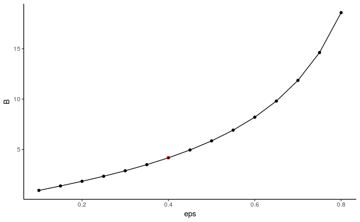

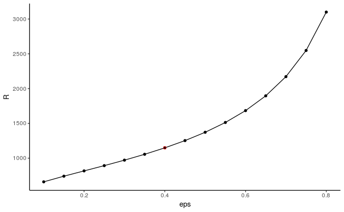

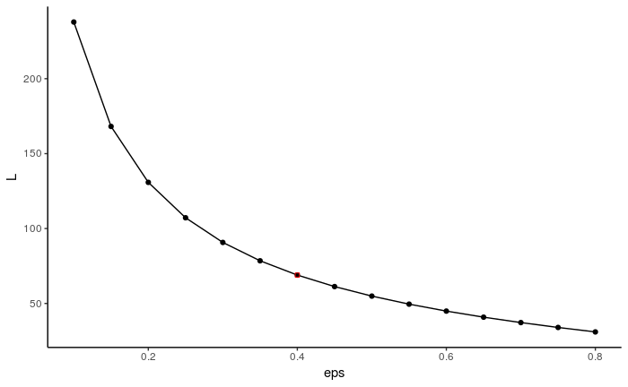

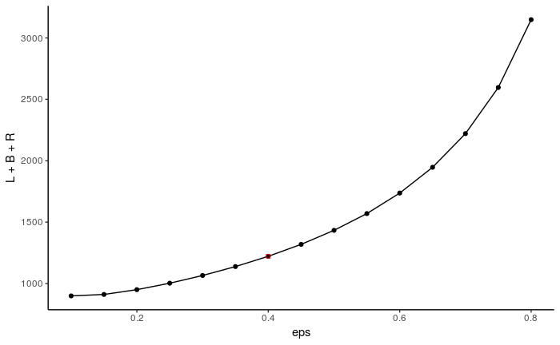

The density-dependent turnover diminishes the effect of litter accumulation with low CUE.